# Biostat 200C Homework 5

Due May 31 @ 11:59PM

Author

Ziheng Zhang_606300061

Published

June 3, 2024

## 1 Q1. Balanced one-way ANOVA random effects model

Consider the balanced one-way ANOVA random effects model with $a$ levels and $n$ observations in each level
$$y_{ij} = \mu + \alpha_i + \epsilon_{ij}, \quad i=1,\ldots,a, \quad j=1,\ldots,n.$$
where $\alpha_i$ are iid from $N(0,\sigma_\alpha^2)$, $\epsilon_{ij}$ are iid from $N(0, \sigma_\epsilon^2)$.

1. Derive the ANOVA estimate for $\mu$, $\sigma_\alpha^2$, and $\sigma_{\epsilon}^2$. Specifically show that
   $$\begin{eqnarray*}
   \mathbb{E}(\bar y_{\cdot \cdot}) &=& \mathbb{E} \left( \frac{\sum_{ij} y_{ij}}{na} \right) = \mu \\
   \mathbb{E} (\text{SSE}) &=& \mathbb{E} \left[ \sum_{i=1}^a \sum_{j=1}^n (y_{ij} - \bar{y}_{i \cdot})^2 \right] = a(n-1) \sigma_{\epsilon}^2 \\
   \mathbb{E} (\text{SSA}) &=& \mathbb{E} \left[ \sum_{i=1}^a \sum_{j=1}^n (\bar{y}_{i \cdot} - \bar{y}_{\cdot \cdot})^2 \right] = (a-1)(n \sigma_{\alpha}^2 + \sigma_{\epsilon}^2),
   \end{eqnarray*}$$
   which can be solved to obtain ANOVA estimate
   $$\begin{eqnarray*}
   \widehat{\mu} &=& \frac{\sum_{ij} y_{ij}}{na}, \\
   \widehat{\sigma}_{\epsilon}^2 &=& \frac{\text{SSE}}{a(n-1)}, \\
   \widehat{\sigma}_{\alpha}^2 &=& \frac{\text{SSA}/(a-1) - \widehat{\sigma}_{\epsilon}^2}{n}.
   \end{eqnarray*}$$

**Answer:**

1. $\mathbb{E}(\bar y_{\cdot \cdot})$
   $$\begin{eqnarray*}
   \mathbb{E}(\bar y_{\cdot \cdot}) &=& \mathbb{E} \left( \frac{\sum_{ij} y_{ij}}{na} \right) = \mathbb{E}\left( \frac{\sum_{ij} \mu + \alpha_i + \epsilon_{ij}}{na}\right) \\
   &=& \frac{\mathbb{E}(\sum_{ij}\mu)}{na} + 0 + 0 \\
   &=& \mu + 0 + 0 = \mu,
   \end{eqnarray*}$$
   since $\alpha_i$ are iid from $N(0, \sigma_{\alpha}^2)$, $\epsilon_{ij}$ are iid $N(0,\sigma_{\epsilon}^2)$, then $\mathbb{E}(\alpha_i) = 0$, $\mathbb{E}(\epsilon_{ij}) = 0$.
2. $\mathbb{E} (\text{SSE})$ and $\mathbb{E} (\text{SSA})$
   $$\text{SSE} = \sum_i \sum_j (y_{ij} - \bar y_{i\cdot})^2 = \mathbf{y}^T \mathbf{A}_1 \mathbf{y}$$
   where
   $$\mathbf{A}_1 = \begin{pmatrix}
   \mathbf{I}_n - n^{-1} \mathbf{1}_n \mathbf{1}_n^T & & \\
   & \ddots & \\
   & & \mathbf{I}_n - n^{-1} \mathbf{1}_n \mathbf{1}_n^T
   \end{pmatrix}.$$
   So
   $$\begin{eqnarray*}
   \mathbb{E} (\text{SSE}) &=& \mathbb{E} \mathbf{y}^T \mathbf{A}_1 \mathbf{y} \\
   &=& \mathbb{E} \operatorname{tr} \mathbf{A}_1 \mathbf{y} \mathbf{y}^T \\
   &=& \operatorname{tr} \mathbf{A}_1 (\sigma_\alpha^2 \mathbf{Z} \mathbf{Z}^T + \sigma_\epsilon^2 \mathbf{I}_{na}) + \mu^2 \operatorname{tr} \mathbf{A}_1 \mathbf{1}_{na} \mathbf{1}_{na}^T \\
   &=& 0 + a (n - 1) \sigma_{\epsilon}^2 + 0 \\
   &=& a (n - 1) \sigma_{\epsilon}^2.
   \end{eqnarray*}$$
   Now
   $$\text{SST} = \mathbf{y}^T \mathbf{A}_0 \mathbf{y},$$
   where $\mathbf{A}_0 = \mathbf{I}_{na} - (na)^{-1} \mathbf{1}_{na} \mathbf{1}_{na}^T$. So
   $$\begin{eqnarray*}
   \mathbb{E}(\text{SST}) &=& \operatorname{tr} \mathbf{A}_0 (\sigma_\alpha^2 \mathbf{Z} \mathbf{Z}^T + \sigma_\epsilon^2 \mathbf{I}_{na}) + \mu^2 \operatorname{tr} \mathbf{A}_0 \mathbf{1}_{na} \mathbf{1}_{na}^T \\
   &=& n (a - 1) \sigma_\alpha^2 + (na - 1) \sigma_{\epsilon}^2 + 0 \\
   &=& n (a - 1) \sigma_\alpha^2 + (na - 1) \sigma_{\epsilon}^2.
   \end{eqnarray*}$$
   Therefore
   $$\mathbb{E}(\text{SSA}) = \mathbb{E}(\text{SST}) - \mathbb{E}(\text{SSE}) = (a - 1)(n \sigma_{\alpha}^2 + \sigma_{\epsilon}^2).$$
2. Derive the MLE estimate for $\mu$, $\sigma_\alpha^2$, and $\sigma_{\epsilon}^2$. Hint: write down the log-likelihood and find the maximizer.

**Answer:**

$$y_{ij} = \mu + \alpha_i + \epsilon_{ij}, \quad i=1,\ldots,a, \quad j=1,\ldots,n.$$
where $\alpha_i$ are iid from $N(0,\sigma_\alpha^2)$, $\epsilon_{ij}$ are iid from $N(0, \sigma_\epsilon^2)$.

**Answer:**
$$\begin{eqnarray*}
L(\mu, \sigma^2_\alpha, \sigma^2_\epsilon) &=& \prod_{i=1}^{a} \left[ \frac{1}{(2\pi)^{n/2}|\Omega|^{1/2}} \exp \left\{ -\frac{1}{2} (\mathbf{y}_i - \mu \mathbf{1}_n)^T \Omega^{-1} (\mathbf{y}_i - \mu \mathbf{1}_n) \right\} \right] \\
\\
\text{where } \Omega &=&
\begin{bmatrix}
\sigma^2_\epsilon + \sigma^2_\alpha & \sigma^2_\alpha & \cdots & \sigma^2_\alpha \\
\sigma^2_\alpha & \sigma^2_\epsilon + \sigma^2_\alpha & \cdots & \sigma^2_\alpha \\
\vdots & \vdots & \ddots & \vdots \\
\sigma^2_\alpha & \sigma^2_\alpha & \cdots & \sigma^2_\epsilon + \sigma^2_\alpha
\end{bmatrix}_{n \times n}
\\
\\
\ell(\mu, \sigma^2_\alpha, \sigma^2_\epsilon) &=& \sum_{i=1}^{a} \left[ -\frac{n}{2}\log(2\pi) - \frac{1}{2} \log|\Omega| - \frac{1}{2} (\mathbf{y}_i - \mu \mathbf{1}_n)^T \Omega^{-1} (\mathbf{y}_i - \mu \mathbf{1}_n) \right] \\
&=&\sum_{i=1}^{a} \left[ -\frac{n}{2}\log(2\pi) - \frac{1}{2} \log|\sigma_{\alpha}^2 \mathbf{1}_n \mathbf{1}_n^T + \sigma_{\epsilon}^2 \mathbf{I}_n| - \frac{1}{2} (\mathbf{y}_i - \mu \mathbf{1}_n)^T (\sigma_{\alpha}^2 \mathbf{1}_n \mathbf{1}_n^T + \sigma_{\epsilon}^2 \mathbf{I}_n)^{-1} (\mathbf{y}_i - \mu \mathbf{1}_n) \right]
\\
\frac{\partial \ell}{\partial \mu} &=& \sum_{i=1}^{a} \Omega^{-1} (\mathbf{y}_i - \mu \mathbf{1}_n)^T \mathbf{1}_n = 0 \\
\Rightarrow \hat{\mu} &=& \frac{\sum_{ij} y_{ij}}{na} = \bar{y}_{\cdot \cdot}\\
\\
\\
\text{By Woodbury formula, }\\
(\sigma_{\alpha}^2 \mathbf{1}_n \mathbf{1}_n^T + \sigma_{\epsilon}^2 \mathbf{I}_n)^{-1} &=& \sigma_{\epsilon}^{-2} \mathbf{I}_{n} - \frac{\sigma_{\epsilon}^{-2} \sigma_{\alpha}^2}{\sigma_{\epsilon}^2 + n\sigma_{\alpha}^2} \mathbf{1}_n \mathbf{1}_n^T \\
\det (\sigma_{\alpha}^2 \mathbf{1}_n \mathbf{1}_n^T + \sigma_{\epsilon}^2 \mathbf{I}_n) &=& \sigma_{\epsilon}^{2n} (1 + n \frac{\sigma_{\alpha}^2}{\sigma_{\epsilon}^2})\\
\\
\ell(\mu, \sigma^2_\alpha, \sigma^2_\epsilon)&=& \sum_{i=1}^{a} \left[ -\frac{n}{2}\log(2\pi) - \frac{1}{2} \log(\sigma_{\epsilon}^{2n} (1 + n \frac{\sigma_{\alpha}^2}{\sigma_{\epsilon}^2})) - \frac{1}{2} (\mathbf{y}_i - \mu \mathbf{1}_n)^T (\sigma_{\epsilon}^{-2} \mathbf{I}_{n} - \frac{\sigma_{\epsilon}^{-2} \sigma_{\alpha}^2}{\sigma_{\epsilon}^2 + n\sigma_{\alpha}^2} \mathbf{1}_n \mathbf{1}_n^T) (\mathbf{y}_i - \mu \mathbf{1}_n) \right]\\
&=& -\frac{na}{2}\log(2\pi) -\frac{na}{2} \log \sigma_{\epsilon}^2 - \frac{a}{2} \log (1 + n\frac{\sigma_{\alpha}^2}{\sigma_{\epsilon}^2}) - \frac{1}{2\sigma_{\epsilon}^{2}} \frac{\text{SST}(\mu) + n\frac{\sigma_{\alpha}^2}{\sigma_{\epsilon}^2} \text{SSA}}{1 + n \frac{\sigma_{\alpha}^2}{\sigma_{\epsilon}^2}}\\
\end{eqnarray*}$$
Let $\lambda = \frac{\sigma_{\alpha}^2}{\sigma_{\epsilon}^2}$ and setting derivative with respect to $\sigma_{\epsilon}^2$ to 0 yields equation
$$\sigma_{\epsilon}^2 = \frac{\text{SST} - \frac{n\lambda}{1 + n\lambda} \text{SSA}}{na} = \frac{\text{SST} + n \lambda \text{SSE}}{na(1 + n\lambda)}.$$
Substitution of the above expression into the log-likelihood shows we need to maximize
$$\begin{eqnarray*}
& & - \frac{na}{2} \log \left( \text{SST} - \frac{n\lambda}{1 + n\lambda} \text{SSA} \right) - \frac{a}{2} \log (1 + n\lambda) \\
&=& - \frac{na}{2} \log \left( \text{SST} + n \lambda \text{SSE} \right) + \frac{(n-1)a}{2} \log (1 + n \lambda).
\end{eqnarray*}$$
Setting derivative to 0 gives the maximizer
$$\hat \lambda = \frac{n-1}{n} \frac{\text{SST}}{\text{SSE}} - 1.$$
Thus
$$\hat \sigma_{\epsilon}^2 = \frac{\text{SST} - \frac{n \hat \lambda}{1 + n \hat \lambda} \text{SSA}}{na} = \frac{\text{SSE}}{(n-1)a}$$
(same as ANOVA estimate) and
$$\hat \sigma_{\alpha}^2 = \frac{\text{SSA}}{an} - \frac{\text{SSE}}{an(n-1)}.$$

3. (**Optional**) Derive the REML estimate for $\mu$, $\sigma_\alpha^2$, and $\sigma_{\epsilon}^2$.

Let $K \in \mathbb{R}^{n \times (n-1)}$ (as fixed effects only contain intercept) be a basis of ${\cal N}(X^T)$. Then
$$K^T Y \sim N(0, K^T \Omega K).$$
and the log-likelihood is
$$\, - \frac 12 \log \det K^T \Omega K - \frac 12 y^T K(K^T \Omega K)^{-1} K^T y.$$
Setting the derivative with respect to $\sigma_\alpha^2$ and $\sigma_\epsilon^2$ to 0 yields the estimation equations
$$\begin{eqnarray*}
\frac{\partial}{\partial \sigma_{\epsilon}^2} \ell &=& - \frac 12 \operatorname{tr} [K(K^T \Omega K)^{-1} K^T] - \frac 12 y^t K(K^T \Omega K)^{-1} K^T K(K^T \Omega K)^{-1} K^T y = 0, \\
\frac{\partial}{\partial \sigma_{\alpha}^2} \ell &=& - \frac 12 \operatorname{tr} [K(K^T \Omega K)^{-1} K^T Z Z^T] - \frac 12 y^t K(K^T \Omega K)^{-1} K^T Z Z^T K(K^T \Omega K)^{-1} K^T y = 0.
\end{eqnarray*}$$

We need to show:
$$K(K^T \Omega K)^{-1} K^T = \Omega^{-1} - \Omega^{-1} X (X^T \Omega^{-1} X)^{-1} X^T \Omega^{-1}.$$
This is because (1) the two sides
$$\Omega^{1/2} K(K^T \Omega K)^{-1} K^T \Omega^{1/2} = I - \Omega^{-1/2} X (X^T \Omega^{-1} X)^{-1} X^T \Omega^{-1/2}$$
are the (unique) orthogonal projection to the space ${\cal C}(X)^\perp = {\cal N}(X^T)$. Or we can prove the relationship as the follows:

Both $KK^{+} := K(K^T K)^{-1}K^T$ and $XX^{+}:=X(X^TX)^{-1}X^T$ are symmetric and idempotent, and $K^TX=0$. Therefore $KK^{+} X = 0$ and $XX^{+} K = 0$. Hence $T = I-KK^{+}-XX^{+}$ is symmetric and idempotent. We have
$$\begin{eqnarray*}
&\mbox{tr}(TT^T) &= \mbox{tr}(T^2) = \mbox{tr}(T) \\
& &=N-r_x-r_k = N-r_x-(N-r_x)=0.
\end{eqnarray*}$$
But $T$ is real, so that $\mbox{tr}(TT^T)=0$ implies that $T=0$. Therefore $KK^{+}=I-XX^{+}$. Because $\Omega=(\Omega^{1/2})^2$. Then, since $(\Omega^{1/2}K)^T\Omega^{-1/2}X=0$, because $K^TX=0$, we can replace $K$ and $X$ by $\Omega^{1/2}K$ and $\Omega^{-1/2}X$ respectively.

4. For all three estimates, check that your results match those we obtained using R for the `pulp` example in class.

**Answer:**

In class, we have

```r
library(faraway)
aovmod <- aov(bright ~ operator, data = pulp) |>
  summary()
```

```r
(aovmod[1][[1]][[3]][1] - aovmod[1][[1]][[3]][2]) / 5
```

```
[1] 0.06808333
```

```r
aovmod[1][[1]][[3]][2]
```

```
[1] 0.10625
```

We can use the following R code to check the results.

```r
library(lme4)
smod <- lmer(bright ~ 1 + (1 | operator), data = pulp, REML = FALSE)
summary(smod)
```

```
Linear mixed model fit by maximum likelihood  ['lmerMod']
Formula: bright ~ 1 + (1 | operator)
   Data: pulp

     AIC      BIC   logLik deviance df.resid
    22.5     25.5     -8.3     16.5       17

Scaled residuals:
     Min       1Q   Median       3Q      Max
-1.50554 -0.78116 -0.06353  0.65850  1.56232

Random effects:
 Groups   Name        Variance Std.Dev.
 operator (Intercept) 0.04575  0.2139
 Residual             0.10625  0.3260
Number of obs: 20, groups:  operator, 4

Fixed effects:
            Estimate Std. Error t value
(Intercept)  60.4000     0.1294   466.7
```

In the R code, the estimate of $\mu$ is the intercept, $60.4$, the estimate of $\sigma^2_\alpha = 0.04575$ and $\sigma^2_\epsilon = 0.10625$.

For MLE, we have $\hat{\mu} = \bar{y}_{\cdot \cdot}$, $\hat \sigma_{\epsilon}^2=\frac{\text{SSE}}{(n-1)a}$ and $\hat \sigma_{\alpha}^2 = \frac{\text{SSA}}{an} - \frac{\text{SSE}}{an(n-1)}$.

```r
mean(pulp$bright)
```

```
[1] 60.4
```

So the MLE estimate of $\mu$ matches the result we obtained in R.

```r
aov(bright ~ operator, data = pulp) |>
  summary()
```

```
            Df Sum Sq Mean Sq F value Pr(>F)
operator     3   1.34  0.4467   4.204 0.0226 *
Residuals   16   1.70  0.1062
---
Signif. codes:  0 '***' 0.001 '**' 0.01 '*' 0.05 '.' 0.1 ' ' 1
```

```r
1.34/(4*5)-1.70/(4*5*4)
```

```
[1] 0.04575
```

```r
1.70/((5-1)*4)
```

```
[1] 0.10625
```

So the MLE estimate of $\sigma^2_\alpha$ and $\sigma^2_\epsilon$ matches the result we obtained in R.

## 2 Q2. Estimation of random effects

1. Assume the conditional distribution
   $$\mathbf{y} \mid \boldsymbol{\gamma} \sim N(\mathbf{X} \boldsymbol{\beta} + \mathbf{Z} \boldsymbol{\gamma}, \sigma^2 \mathbf{I}_n)$$
   and the prior distribution
   $$\boldsymbol{\gamma} \sim N(\mathbf{0}_q, \boldsymbol{\Sigma}).$$
   Then by the Bayes theorem, the posterior distribution is
   $$\begin{eqnarray*}
   f(\boldsymbol{\gamma} \mid \mathbf{y}) &=& \frac{f(\mathbf{y} \mid \boldsymbol{\gamma}) \times f(\boldsymbol{\gamma})}{f(\mathbf{y})}, \end{eqnarray*}$$
   where $f$ denotes corresponding density. Show that the posterior distribution is a multivariate normal with mean
   $$\mathbb{E} (\boldsymbol{\gamma} \mid \mathbf{y}) = \boldsymbol{\Sigma} \mathbf{Z}^T (\mathbf{Z} \boldsymbol{\Sigma} \mathbf{Z}^T + \sigma^2 \mathbf{I})^{-1} (\mathbf{y} - \mathbf{X} \boldsymbol{\beta}).$$
   **Answer:**

By Bayes theorem, we have
$$\begin{eqnarray*}
f(\boldsymbol{\gamma} \mid \mathbf{y}) &=& \frac{f(\mathbf{y} \mid \boldsymbol{\gamma}) \times f(\boldsymbol{\gamma})}{f(\mathbf{y})}\\
&\propto& \exp\left(-\frac{1}{2\sigma^2}(\mathbf{y} - \mathbf{X} \boldsymbol{\beta} - \mathbf{Z} \boldsymbol{\gamma})^T (\mathbf{y} - \mathbf{X} \boldsymbol{\beta} - \mathbf{Z} \boldsymbol{\gamma})\right) \times \exp\left(-\frac{1}{2} \boldsymbol{\gamma}^T \boldsymbol{\Sigma}^{-1} \boldsymbol{\gamma}\right)\\
&=& \exp\left(-\frac{1}{2\sigma^2}(\mathbf{y} - \mathbf{X} \boldsymbol{\beta} - \mathbf{Z} \boldsymbol{\gamma})^T (\mathbf{y} - \mathbf{X} \boldsymbol{\beta} - \mathbf{Z} \boldsymbol{\gamma}) - \frac{1}{2} \boldsymbol{\gamma}^T \boldsymbol{\Sigma}^{-1} \boldsymbol{\gamma}\right)\\
&\propto& \exp\left(-\frac{1}{2}\left[\boldsymbol{\gamma}^T\left(\frac{\mathbf{Z}^T\mathbf{Z}}{\sigma^2}+\boldsymbol{\Sigma}^{-1}\right)\boldsymbol{\gamma}-\frac{2}{\sigma^2}(\boldsymbol{\gamma}^T\mathbf{Z}^T(\mathbf{y} - \mathbf{X} \boldsymbol{\beta})) \right]\right), \text{since }\boldsymbol{\gamma}^T\mathbf{Z}^T(\mathbf{y} - \mathbf{X} \boldsymbol{\beta}) \text{ is a scalar}\\
&=&\exp\left(-\frac{1}{2}\left[\boldsymbol{\gamma}^T\left(\sigma^{-2}\mathbf{Z}^T\mathbf{Z}+\boldsymbol{\Sigma}^{-1}\right)\boldsymbol{\gamma}-\frac{2}{\sigma^2}(\boldsymbol{\gamma}^T(\sigma^{-2} \mathbf{Z}^T \mathbf{Z} + \boldsymbol{\Sigma}^{-1}) (\sigma^{-2} \mathbf{Z}^T \mathbf{Z} + \boldsymbol{\Sigma}^{-1})^{-1 }\mathbf{Z}^T(\mathbf{y} - \mathbf{X} \boldsymbol{\beta})) \right]\right)
\end{eqnarray*}$$
It’s clear the covariance of posterior normal distribution is
$$(\sigma^{-2} \mathbf{Z}^T \mathbf{Z} + \boldsymbol{\Sigma}^{-1})^{-1} = \boldsymbol{\Sigma} - \boldsymbol{\Sigma} \mathbf{Z}^T (\sigma^2 \mathbf{I_n} + \mathbf{Z} \mathbf{Z}^T)^{-1} \mathbf{Z} \boldsymbol{\Sigma}.$$
Now by binomial inversion
$$\begin{eqnarray*}
& & \sigma^{-2} (\sigma^{-2} \mathbf{Z}^T \mathbf{Z} + \Sigma^{-1})^{-1 } \mathbf{Z}^T (\mathbf{y} - \mathbf{X} \boldsymbol{\beta}) \\
&=& \sigma^{-2} [\Sigma \mathbf{Z}^T - \Sigma \mathbf{Z}^T (\mathbf{Z} \Sigma \mathbf{Z}^T + \sigma^2 \mathbf{I})^{-1} \mathbf{Z} \Sigma \mathbf{Z}^T] (\mathbf{y} - \mathbf{X} \boldsymbol{\beta}) \\
&=& \sigma^{-2} \Sigma \mathbf{Z}^T [\mathbf{I} - (\mathbf{Z} \Sigma \mathbf{Z}^T + \sigma^2 \mathbf{I})^{-1} \mathbf{Z} \Sigma \mathbf{Z}^T] (\mathbf{y} - \mathbf{X} \boldsymbol{\beta}) \\
&=& \sigma^{-2} \Sigma \mathbf{Z}^T [(\mathbf{Z} \Sigma \mathbf{Z}^T + \sigma^2 \mathbf{I})^{-1} (\mathbf{Z} \Sigma \mathbf{Z}^T + \sigma^2 \mathbf{I}) - (\mathbf{Z} \Sigma \mathbf{Z}^T + \sigma^2 \mathbf{I})^{-1} \mathbf{Z} \Sigma \mathbf{Z}^T] (\mathbf{y} - \mathbf{X} \boldsymbol{\beta}) \\
&=& \Sigma \mathbf{Z}^T (\mathbf{Z} \Sigma \mathbf{Z}^T + \sigma^2 \mathbf{I})^{-1} (\mathbf{y} - \mathbf{X} \boldsymbol{\beta}).
\end{eqnarray*}$$
So
$$\begin{eqnarray*}
f(\boldsymbol{\gamma} \mid \mathbf{y}) &\propto& \exp\left(-\frac{1}{2}\left[\boldsymbol{\gamma}^T\left(\sigma^{-2}\mathbf{Z}^T\mathbf{Z}+\boldsymbol{\Sigma}^{-1}\right)\boldsymbol{\gamma}-2(\boldsymbol{\gamma}^T(\sigma^{-2} \mathbf{Z}^T \mathbf{Z} + \boldsymbol{\Sigma}^{-1}) (\boldsymbol{\Sigma} \mathbf{Z}^T (\mathbf{Z} \boldsymbol{\Sigma} \mathbf{Z}^T + \sigma^2 I)^{-1} (\mathbf{y} - \mathbf{X} \boldsymbol{\beta})) \right]\right)\\
&=& \exp\left(-\frac{1}{2}\left(\sigma^{-2}\mathbf{Z}^T\mathbf{Z}+\boldsymbol{\Sigma}^{-1}\right)\left[\boldsymbol{\gamma}^T\boldsymbol{\gamma}-2(\boldsymbol{\gamma}^T (\boldsymbol{\Sigma} \mathbf{Z}^T (\mathbf{Z} \boldsymbol{\Sigma} \mathbf{Z}^T + \sigma^2 I)^{-1} (\mathbf{y} - \mathbf{X} \boldsymbol{\beta})) \right]\right)
\end{eqnarray*}$$
So
$$\mathbb{E} (\boldsymbol{\gamma} \mid \mathbf{y}) = \boldsymbol{\Sigma} \mathbf{Z}^T (\mathbf{Z} \boldsymbol{\Sigma} \mathbf{Z}^T + \sigma^2 \mathbf{I})^{-1} (\mathbf{y} - \mathbf{X} \boldsymbol{\beta})$$

2. For the balanced one-way ANOVA random effects model, show that the posterior mean of random effects is always a constant (less than 1) multiplying the corresponding fixed effects estimate.

**Answer:** For the balanced one-way ANOVA random effects model, we know
$$\begin{eqnarray*}
\mathbf{y} = \mathbf{1}_{na} \mu + \begin{pmatrix}
\mathbf{1}_{n} & & \\
& \vdots & \\
& & \mathbf{1}_{n}
\end{pmatrix} \boldsymbol{\gamma} + \boldsymbol{\epsilon}\\
\text{So Z here is } \begin{pmatrix}
\mathbf{1}_{n} & & \\
& \vdots & \\
& & \mathbf{1}_{n}
\end{pmatrix}
\end{eqnarray*}$$
So the posterior mean of random effects is
$$\begin{eqnarray*}
\mathbb{E} (\boldsymbol{\gamma} \mid \mathbf{y}) &=& \boldsymbol{\Sigma} \mathbf{Z}^T (\mathbf{Z} \boldsymbol{\Sigma} \mathbf{Z}^T + \sigma^2 \mathbf{I})^{-1} (\mathbf{y} - \mathbf{X} \boldsymbol{\beta})\\
&=& \sigma_{\epsilon}^{-2} (\sigma_{\epsilon}^{-2} \mathbf{Z}^T \mathbf{Z} + \Sigma_{\epsilon}^{-1})^{-1 } \mathbf{Z}^T (\mathbf{y} - \mathbf{X} \boldsymbol{\beta}) \\
\mathbf{Z}^T \mathbf{Z} &=& n \mathbf{I}_a, \quad \Sigma_{\epsilon} = \sigma_{\alpha}^2 \mathbf{I}_a\\
\mathbb{E} (\boldsymbol{\gamma} \mid \mathbf{y})&=& \begin{pmatrix}
\frac{1}{n + (\sigma_{\epsilon}/\sigma_{\alpha})^2} & & \\
& \vdots & \\
& & \frac{1}{n + (\sigma_{\epsilon}/\sigma_{\alpha})^2}
\end{pmatrix} \begin{pmatrix}
n\bar{y}_{1\cdot} - n\hat \mu \\
\vdots \\
n\bar{y}_{a\cdot} - n\hat \mu
\end{pmatrix} \\
&=&\frac{n}{n + (\sigma_{\epsilon}/\sigma_{\alpha})^2}\begin{pmatrix}
\bar{y}_{1\cdot} - \hat \mu \\
\vdots \\
\bar{y}_{a\cdot} - \hat \mu
\end{pmatrix} \\
&=& \frac{1}{1 + n^{-1}(\sigma_{\epsilon}/\sigma_{\alpha})^2} \begin{pmatrix}
\hat \alpha_1 \\
\vdots \\
\hat \alpha_a
\end{pmatrix}.
\end{eqnarray*}$$
Since $n^{-1}(\sigma_{\epsilon}/\sigma_{\alpha})^2>0$, the posterior mean of random effects is always a constant (less than 1) multiplying the corresponding fixed effects estimate.

## 3 Q3. ELMR Exercise 11.1 (p251)

The ratdrink data consist of five weekly measurements of body weight for 27 rats. The first 10 rats are on a control treatment while 7 rats have thyroxine added to their drinking water. Ten rats have thiouracil added to their water.

### 3.1 Q3.1

1. Plot the data showing how weight increases with age on a single panel, taking care to distinguish the three treatment groups. Now create a three-panel plot, one for each group. Discuss what can be seen.

**Answer:**

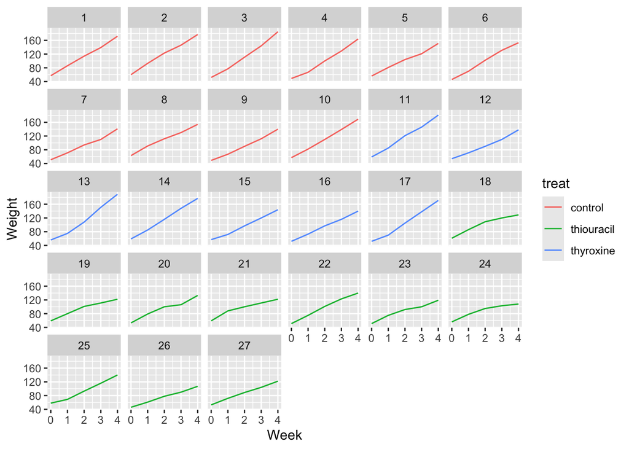

```r
library(ggplot2)
library(gridExtra)
library(tidyverse)
ggplot(data = ratdrink, aes(x = weeks, y = wt, color = treat)) +
  geom_line() +
  facet_wrap(~subject) +
  labs(x = "Week", y = "Weight")
```

From this plot, we can see that the weight increases with age for all three treatment groups.

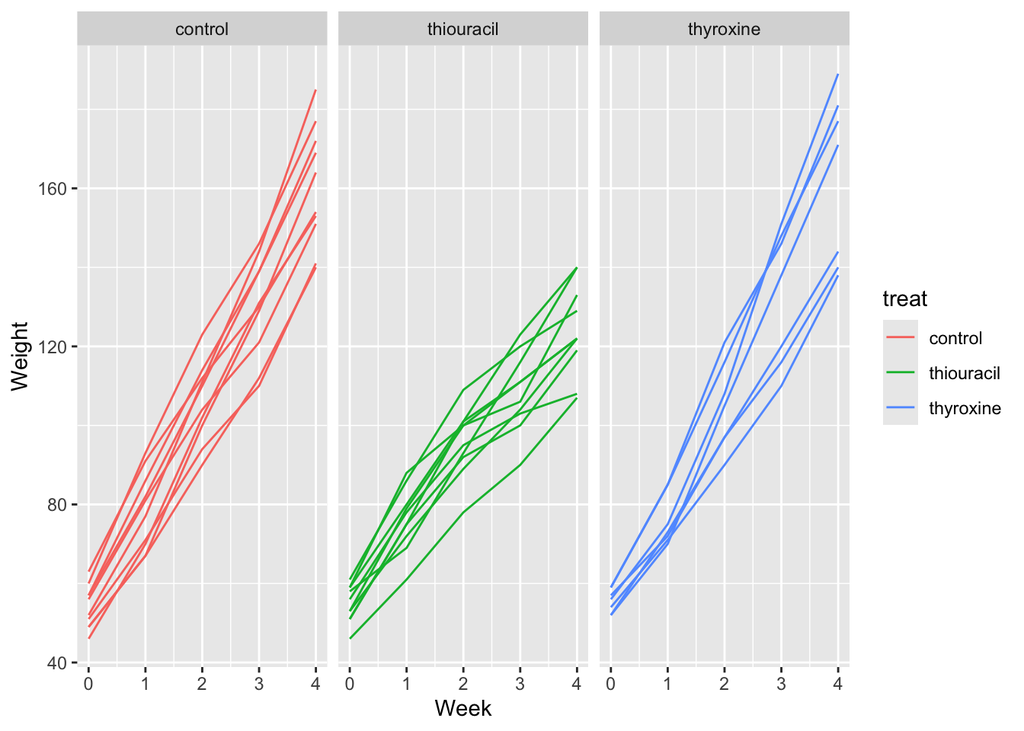

```r
ggplot(data = ratdrink, aes(x = weeks, y = wt, group = subject,
                            color = treat)) +
  geom_line() +
  facet_wrap(~treat) +
  labs(x = "Week", y = "Weight")
```

Control rats and thyroxine treated rats have similar weight gain over time, while thiouracil treated rats have a lower weight gain over time.

### 3.2 Q3.2

2. Fit a linear longitudinal model that allows for a random slope and intercept for each rat. Each group should have a different mean line. Give interpretation for the following estimates:
1. The fixed effect intercept term.
2. The interaction between thiouracil and week.
3. The intercept random effect SD.

**Answer:**

```r
library(lme4)
m1 <- lmer(wt ~ weeks * treat + (weeks | subject), data = ratdrink)
summary(m1)
```

```
Linear mixed model fit by REML ['lmerMod']
Formula: wt ~ weeks * treat + (weeks | subject)
   Data: ratdrink

REML criterion at convergence: 878.7

Scaled residuals:
     Min       1Q   Median       3Q      Max
-1.83136 -0.54991  0.04003  0.58230  2.03660

Random effects:
 Groups   Name        Variance Std.Dev. Corr
 subject  (Intercept) 32.49    5.700
          weeks       14.14    3.760    -0.13
 Residual             18.90    4.348
Number of obs: 135, groups:  subject, 27

Fixed effects:
                      Estimate Std. Error t value
(Intercept)            52.8800     2.0937  25.256
weeks                  26.4800     1.2661  20.915
treatthiouracil         4.7800     2.9610   1.614
treatthyroxine         -0.7943     3.2628  -0.243
weeks:treatthiouracil  -9.3700     1.7905  -5.233
weeks:treatthyroxine    0.6629     1.9730   0.336

Correlation of Fixed Effects:
            (Intr) weeks  trtthr trtthy wks:trtthr
weeks       -0.250
treatthircl -0.707  0.177
treatthyrxn -0.642  0.160  0.454
wks:trtthrc  0.177 -0.707 -0.250 -0.113
wks:trtthyr  0.160 -0.642 -0.113 -0.250  0.454
```

- The fixed effect intercept term: The estimated average weight of the control group at week 0 is 52.88.
- The interaction between thiouracil and week: For every one week increase, the estimated average weight gain for the thiouracil group is -9.37 weights lower than that for the control group.
- The intercept random effect SD: The standard deviation between subjects within the same treatment group is 5.7.

### 3.3 Q3.3

3. Check whether there is a significant treatment effect.

**Answer:**

```r
library(pbkrtest)
m2 <- lmer(wt ~ weeks + (weeks | subject), data = ratdrink)
KRmodcomp(m1, m2)
```

```
large : wt ~ weeks * treat + (weeks | subject)
small : wt ~ weeks + (weeks | subject)
         stat     ndf     ddf F.scaling   p.value
Ftest  8.7125  4.0000 26.8141   0.94552 0.0001215 ***
---
Signif. codes:  0 '***' 0.001 '**' 0.01 '*' 0.05 '.' 0.1 ' ' 1
```

The p-value is 0.0001215, which is less than 0.05. Therefore, there is a significant treatment effect.

### 3.4 Q3.4

4. Construct diagnostic plots showing the residuals against the fitted values and a QQ plot of the residuals. Interpret.

**Answer:**

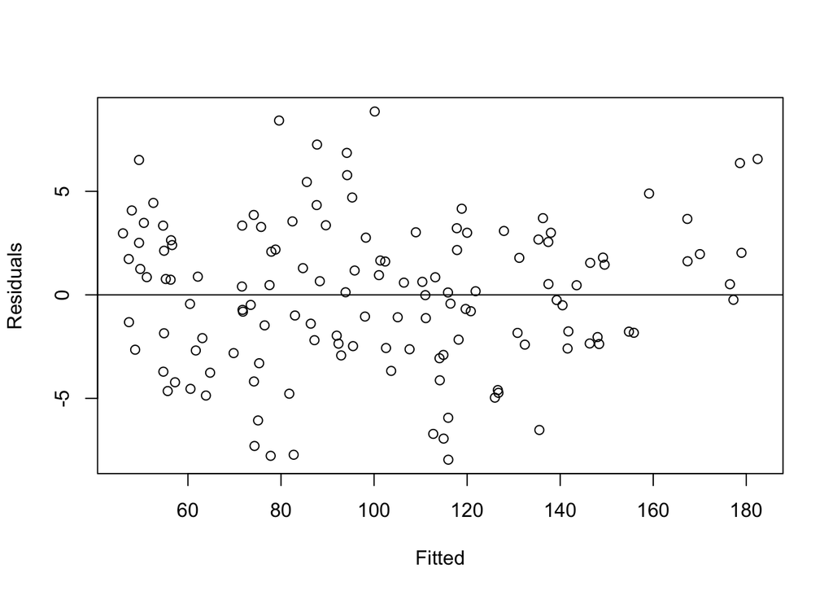

```r
plot(resid(m1) ~ fitted(m1), xlab = "Fitted", ylab = "Residuals")
abline(h=0)
```

The residuals are randomly scattered around the 0 line and there is no special pattern, indicating that the linearity and constant variance assumptions are met.

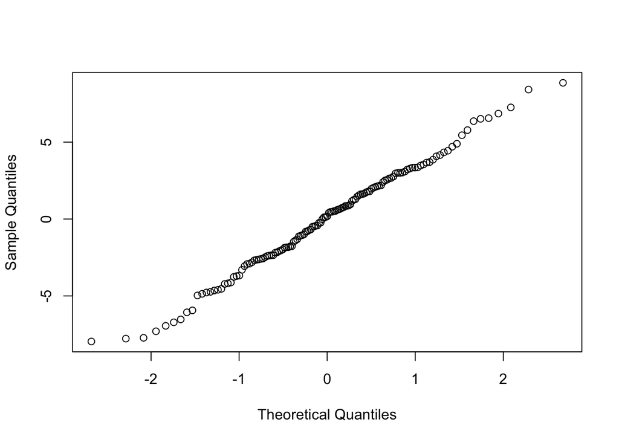

```r
qqnorm(resid(m1), main = "")
```

The residuals are close to a straight line, indicating that the normality assumption is met.

### 3.5 Q3.5

5. Construct confidence intervals for the parameters of the model. Which random effect terms may not be significant? Is the thyroxine group significantly different from the control group?

**Answer:**

```r
confint(m1, method = "boot")
```

```
                            2.5 %     97.5 %
.sig01                  3.4994519  7.7535801
.sig02                 -0.5640239  0.5027692
.sig03                  2.4404461  4.8876590
.sigma                  3.6634824  4.9860911
(Intercept)            48.8704652 56.9354323
weeks                  23.7646689 29.0967885
treatthiouracil        -0.7277688 10.8806278
treatthyroxine         -7.2043999  5.4367604
weeks:treatthiouracil -12.6932258 -5.4910512
weeks:treatthyroxine   -3.2033677  4.0122335
```

## 4 Q4. ELMR Exercise 13.1 (p295)

The ohio data concern 536 children from Steubenville, Ohio and were taken as part of a study on the effects of air pollution. Children were in the study for 4 years from ages 7 to 10. The response was whether they wheezed or not. The variables are:

`resp` an indicator of wheeze status (1 = yes, 0 = no)

`id` an identifier for the child

`age` 7 yrs = −2, 8 yrs = −1, 9 yrs =0, 10 yrs = 1

`smoke` an indicator of maternal smoking at the first year of the study (1=smoker, 0 = nonsmoker)

### 4.1 Q4.1

1. Do any of the mothers in the study change their smoking status during the period of observation?

**Answer:**

```r
ohio |>
  group_by(id) |>
  summarise(smoke_change = n_distinct(smoke))
```

```
# A tibble: 537 × 2
      id smoke_change
   <int>        <int>
 1     0            1
 2     1            1
 3     2            1
 4     3            1
 5     4            1
 6     5            1
 7     6            1
 8     7            1
 9     8            1
10     9            1
# ℹ 527 more rows
```

```r
sum(ohio$smoke_change > 1)
```

```
[1] 0
```

There are 0 mothers who changed their smoking status during the period of observation because the number of distinct smoking statuses is equal to 1 for all mothers, which means they did not change their smoking status.

### 4.2 Q4.2

2. Construct a table that shows proportion of children who wheeze for 0, 1, 2, 3 or 4 years broken down by maternal smoking status.

**Answer:**

```r
table_data <- ohio |>
  group_by(id, smoke) |>
  summarise(years = sum(resp), .groups = "drop")

prop.table(table(table_data$years, table_data$smoke), 2)
```

```
             0          1
  0 0.67714286 0.63101604
  1 0.18571429 0.17112299
  2 0.07142857 0.10160428
  3 0.03428571 0.05882353
  4 0.03142857 0.03743316
```

### 4.3 Q4.3

3. Make plot which shows how the proportion of children wheezing changes by age with a separate line for smoking and nonsmoking mothers.

**Answer:**

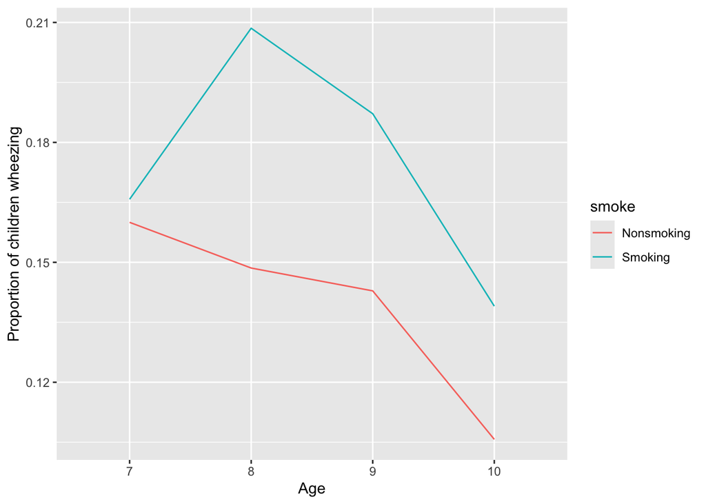

```r
library(ggplot2)
ohio |>
  count(age, smoke, resp) |>
  group_by(age, smoke) |>
  mutate(prop = prop.table(n)) |>
  filter(resp == 1) |>
  mutate(age = factor(age, levels = c(-2, -1, 0, 1),
         labels = c(7, 8, 9, 10)),
         smoke = factor(smoke, levels = c(0, 1),
                        labels = c("Nonsmoking", "Smoking"))) |>
  ungroup() |>
  ggplot(aes(x = age, y = prop, color = smoke, group = smoke)) +
  geom_line() +
  labs(x = "Age", y = "Proportion of children wheezing")
```

### 4.4 Q4.4

4. Group the data by child to count the total (out of four) years of wheezing. Fit a binomial GLM to this response to check for a maternal smoking effect. Does this prove there is a smoking effect or could there be another plausible explanation?

**Answer:**

```r
ohio1 <- ohio |>
  group_by(id) |>
  summarise(whez_years = sum(resp)) |>
  mutate(non_whez_years = 4 - whez_years) |>
  mutate(smoke = ohio$smoke[match(id, ohio$id)], .after = non_whez_years)
glm(cbind(whez_years, non_whez_years) ~ smoke, data = ohio1,
    family = binomial) |>
  summary()
```

```
Call:
glm(formula = cbind(whez_years, non_whez_years) ~ smoke, family = binomial,
    data = ohio1)

Coefficients:
            Estimate Std. Error z value Pr(>|z|)
(Intercept) -1.82124    0.07719 -23.595   <2e-16 ***
smoke        0.27156    0.12334   2.202   0.0277 *
---
Signif. codes:  0 '***' 0.001 '**' 0.01 '*' 0.05 '.' 0.1 ' ' 1

(Dispersion parameter for binomial family taken to be 1)

    Null deviance: 1045.3  on 536  degrees of freedom
Residual deviance: 1040.5  on 535  degrees of freedom
AIC: 1337.9

Number of Fisher Scoring iterations: 4
```

The p-value of `smoke` is $0.0277 <0.05$, which indicates that there is a maternal smoking effect. However, there could be another plausible explanation because there could be something confounding the results.

### 4.5 Q4.5

5. Fit a model for each individual response using a GLMM fit using penalized quasi-likelihood. Describe the effects of age and maternal smoking. How do the odds of wheezing change numerically over time?

**Answer:**

```r
library(MASS)
pqlmod <- glmmPQL(resp ~ age + smoke, random = ~ 1 | id, family = binomial, data = ohio)
summary(pqlmod)
```

```
Linear mixed-effects model fit by maximum likelihood
  Data: ohio
  AIC BIC logLik
   NA  NA     NA

Random effects:
 Formula: ~1 | id
        (Intercept)  Residual
StdDev:    2.057175 0.6355563

Variance function:
 Structure: fixed weights
 Formula: ~invwt
Fixed effects:  resp ~ age + smoke
                 Value  Std.Error   DF    t-value p-value
(Intercept) -2.7658365 0.14218299 1610 -19.452654  0.0000
age         -0.1815756 0.04365164 1610  -4.159652  0.0000
smoke        0.3251839 0.23131699  535   1.405793  0.1604
 Correlation:
      (Intr) age
age    0.197
smoke -0.591 -0.003

Standardized Within-Group Residuals:
       Min         Q1        Med         Q3        Max
-2.6145143 -0.2829352 -0.2583719 -0.2154580  3.4443795

Number of Observations: 2148
Number of Groups: 537
```

For every one year increase in age, the odds of wheezing decreases by $1- e^{-0.182} = 16.6\%$, controlling for smoking condition. The odds of wheezing for children of smoking mothers are $e^{0.325} = 1.384$ times higher than that for children of nonsmoking mothers, controlling for age. The odds of wheezing decreases by $1- e^{-0.182} = 16.6\%$ over time.

### 4.6 Q4.6

6. Now fit the same model but using adaptive Gaussian-Hermit quadrature. Compare to the previous model fit.

**Answer:**

```r
library(lme4)
ghmod <- glmer(resp ~ age + smoke + (1 | id), nAGQ = 25, family = binomial,
               data = ohio)
summary(ghmod)
```

```
Generalized linear mixed model fit by maximum likelihood (Adaptive
  Gauss-Hermite Quadrature, nAGQ = 25) [glmerMod]
 Family: binomial  ( logit )
Formula: resp ~ age + smoke + (1 | id)
   Data: ohio

     AIC      BIC   logLik deviance df.resid
  1603.3   1626.0   -797.6   1595.3     2144

Scaled residuals:
    Min      1Q  Median      3Q     Max
-1.3730 -0.2011 -0.1773 -0.1487  2.5076

Random effects:
 Groups Name        Variance Std.Dev.
 id     (Intercept) 4.687    2.165
Number of obs: 2148, groups:  id, 537

Fixed effects:
            Estimate Std. Error z value Pr(>|z|)
(Intercept) -3.10152    0.21905 -14.159  < 2e-16 ***
age         -0.17563    0.06768  -2.595  0.00946 **
smoke        0.39856    0.27309   1.459  0.14444
---
Signif. codes:  0 '***' 0.001 '**' 0.01 '*' 0.05 '.' 0.1 ' ' 1

Correlation of Fixed Effects:
      (Intr) age
age    0.244
smoke -0.493 -0.008
```

The coefficients of `age` and `smoke` are similar to the previous model fit. For every one year increase in age, the odds of wheezing decreases by $1- e^{-0.176} = 16.1\%$, controlling for smoking condition. The odds of wheezing for children of smoking mothers are $e^{0.399} = 1.49$ times higher than that for children of nonsmoking mothers, controlling for age. The odds of wheezing decreases by $1- e^{-0.176} = 16.1\%$ over time.

### 4.7 Q4.7

7. Use INLA to fit the same model. What does this model say about the effect of age and maternal smoking (optional)?

**Answer:**

```r
library(INLA)
formula <- resp ~ age + smoke + f(id, model = "iid")
inlamod <- inla(formula, family = "binomial", data = ohio)
summary(inlamod)
```

```
Time used:
    Pre = 1.6, Running = 1.44, Post = 0.0463, Total = 3.09
Fixed effects:
              mean    sd 0.025quant 0.5quant 0.975quant   mode kld
(Intercept) -2.945 0.201     -3.362   -2.937     -2.573 -2.907   0
age         -0.173 0.063     -0.297   -0.173     -0.050 -0.173   0
smoke        0.385 0.239     -0.083    0.384      0.858  0.384   0

Random effects:
  Name    Model
    id IID model

Model hyperparameters:
                  mean    sd 0.025quant 0.5quant 0.975quant  mode
Precision for id 0.276 0.047      0.196    0.272      0.379 0.266

Marginal log-Likelihood:  -834.98
 is computed
Posterior summaries for the linear predictor and the fitted values are computed
(Posterior marginals needs also 'control.compute=list(return.marginals.predictor=TRUE)')
```

For every one year increase in age, the odds of wheezing decreases by $1- e^{-0.173} = 15.9\%$, controlling for smoking condition. The odds of wheezing for children of smoking mothers are $e^{0.385} = 1.47$ times higher than that for children of nonsmoking mothers, controlling for age.

### 4.8 Q4.8

8. Use STAN to fit the same model. Check the MCMC diagnostics and again discuss the age and maternal smoking effects (optional).

### 4.9 Q4.9

1. Fit the model using GEE. Use an autoregressive rather than exchangeable error structure. Compare the results to the previous model fits. In your model, what indicates that a child who already wheezes is likely to continue to wheeze?

**Answer:**

```r
library(geepack)
geemod <- geeglm(resp ~ age + smoke, id = id, corstr = "ar1", data = ohio,
                 family =binomial(link = "logit"))
summary(geemod)
```

```
Call:
geeglm(formula = resp ~ age + smoke, family = binomial(link = "logit"),
    data = ohio, id = id, corstr = "ar1")

 Coefficients:
            Estimate  Std.err    Wald Pr(>|W|)
(Intercept) -1.90218  0.11525 272.409   <2e-16 ***
age         -0.11489  0.04539   6.407   0.0114 *
smoke        0.23448  0.18119   1.675   0.1956
---
Signif. codes:  0 '***' 0.001 '**' 0.01 '*' 0.05 '.' 0.1 ' ' 1

Correlation structure = ar1
Estimated Scale Parameters:

            Estimate Std.err
(Intercept)    1.021  0.1232
  Link = identity

Estimated Correlation Parameters:
      Estimate Std.err
alpha    0.491 0.06733
Number of clusters:   537  Maximum cluster size: 4
```

For every one year increase in age, the odds of wheezing decreases by $1- e^{-0.115} = 10.86\%$, controlling for smoking condition. The odds of wheezing for children of smoking mothers are $e^{0.233} = 1.262$ times higher than that for children of nonsmoking mothers, controlling for age. The odds of wheezing decreases by $1- e^{-0.115} = 10.86\%$ over time. The correlation coefficient of the autoregressive error structure is $0.5$, which indicates that a child who already wheezes is likely to continue to wheeze.

### 4.10 Q4.10

10. What is your overall conclusion regarding the effect of age and maternal smoking? Can we trust the GLM result or are the GLMM models preferable?

**Answer:** The `age` has a significant effect on the odds of wheezing while `smoke` does not have a significant effect on the odds of wheezing. The GLMM models are preferable because they consider the dependency between the repeated measurements of the same child.